# Homework #4 Key

Amounts

Due: 26 Jan 2021

## Concepts

1. Explain how statistical transformations are related to geometric objects.

Statistical transformations complete the calculations that are necessary to create a geometric object. For example, the default stat for geom_bar is stat_count. Before drawing a bar chart, it is necessary to count the number of observations in each category.

2. Explain why you should not use Pareto Charts with ordinal categorical variables.

Ordinal categorical variables have a natural ordering. Pareto charts reorder categories based on frequency of occurrence. The natural ordering has meaning and should be preserved.

## Code Interpretation

Problem #1 MPG

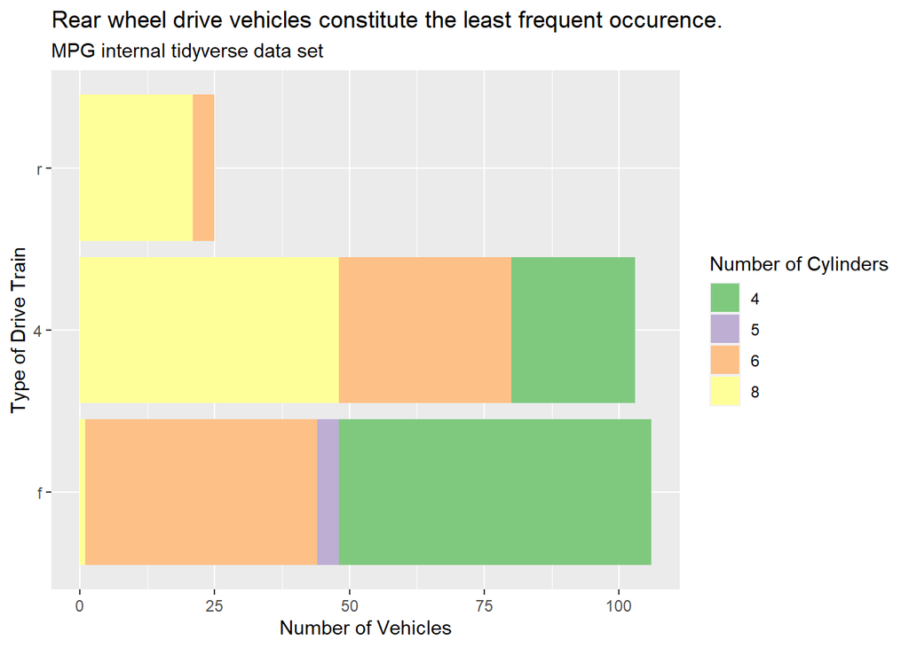

```r
ggplot(data = mpg, mapping = aes(y = fct_infreq(drv), fill = as.factor(cyl))) +
  geom_bar() +
  scale_fill_brewer(palette = "Accent") +
  labs(
    title = "Rear wheel drive vehicles constitute the least frequent occurence.",
    subtitle = "MPG internal tidyverse data set",
    fill = "Number of Cylinders",
    y = "Type of Drive Train",
    x = "Number of Vehicles"
  )
```

Line 1: In addition to specifying the data set and variable for the bar chart, the fct_infreq function orders the drv levels from by their frequency. Without the fct_infreq function, the levels are ordered alphabetically. The as.factor function is needed because cyl is numeric and need to be treated as a factor in order for the fill mapping to work.

Line 2: Adds a bar layer to the graph. Implicit in this geom is a stat which counts how many observations fit into each level of the drv variable.

Line 3: Specifies that the fill use the Accent palette from the color brewer project.

Lines 4-10: Labels and titles for the plot

Problem #2 Diamonds

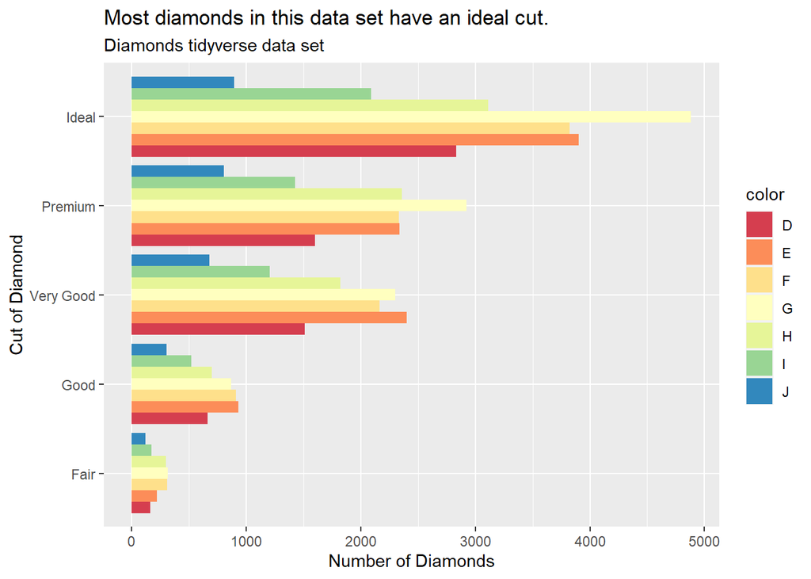

```r
ggplot(data = diamonds, mapping = aes(y = cut, fill = color)) +
  geom_bar(position = "dodge") +
  scale_fill_brewer(palette = "Spectral") +
  labs(
    title = "Most diamonds in this data set have an ideal cut.",
    subtitle = "Diamonds tidyverse data set",
    y = "Cut of Diamond",
    x = "Number of Diamonds"
  )
```

Line 2: Counts the frequency for each color of diamond and created a side by side bar chart. Position = “dodge” converts the bar chart into side by side.

Line 3: Used the “Spectral” palette from the color brewer project.

Lines 4-9: Titles and label the plot.

## Coding

Problem 1

- Use the mpg data frame
- Verticle bar chart based on the class of vehicle
- Fill the bars based on the type of drive train
- Scale colors using brewer palette “Accent”
- Add the labels and titles as shown

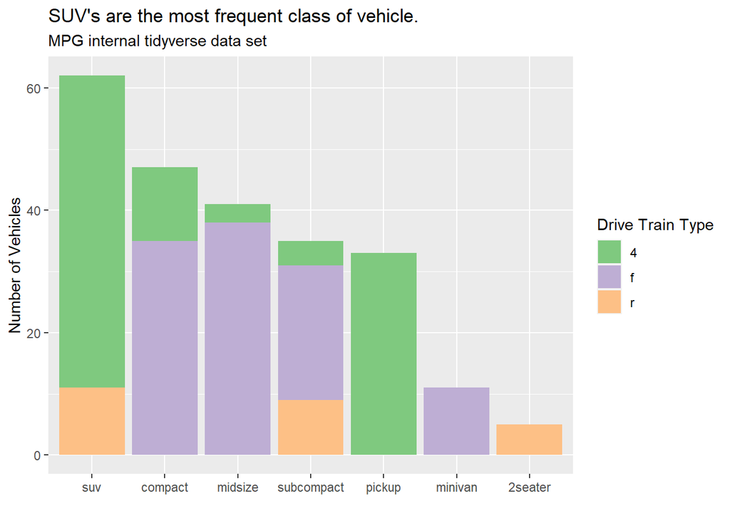

```r
ggplot(data = mpg, mapping = aes(x = fct_infreq(class), fill = drv)) +
  geom_bar() +
  scale_fill_brewer(palette = "Accent") +
  labs(
    title = "SUV's are the most frequent class of vehicle.",
    subtitle = "MPG internal tidyverse data set",
    fill = "Drive Train Type",
    x = "",
    y = "Number of Vehicles"
  )
```

Problem 2

- Diamonds data frame
- Horizontal bar chart of cut
- Fill each bar based on the color of the diamond
- Scale fill using brewer palette “Pastel1”
- Add the labels and titles as shown

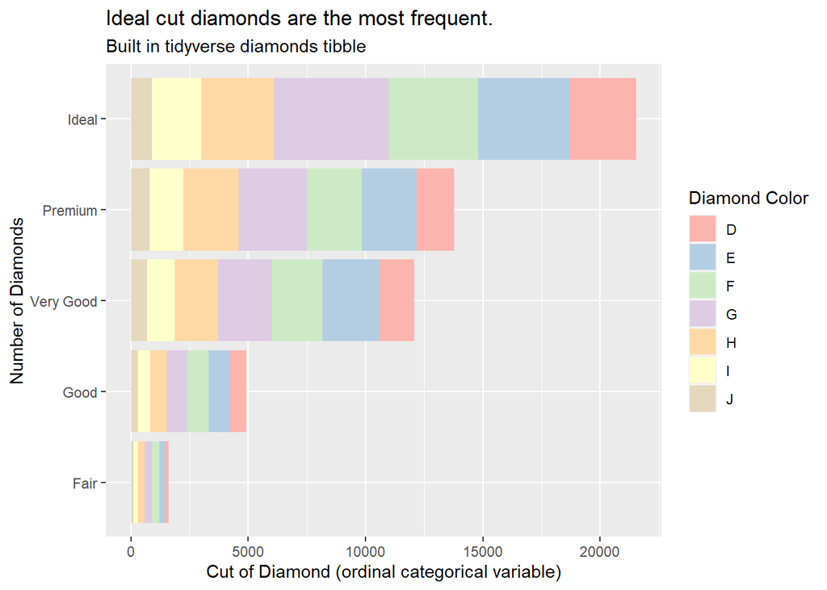

```r
ggplot(data = diamonds, mapping = aes(y = cut, fill = color)) +
  geom_bar() +
  scale_fill_brewer(palette = "Pastel1") +
  labs(
    title = "Ideal cut diamonds are the most frequent.",
    subtitle = "Built in tidyverse diamonds tibble",
    x = "Cut of Diamond (ordinal categorical variable)",
    y = "Number of Diamonds",
    fill = "Diamond Color"
  )
```